# Truncated Peptide Sequences of Protein Coding Genes in mTECs

Léonie Strömich

August 23, 2017

This script is used to retrieve the amino acid sequence of the truncated peptide when considering the main TSS (highest tag count) as true TSS in mTECs. The peptide sequence as well as the length are stored as additional information to characterise protein coding genes in mTECs. The truncation length can also be used as additional filter to obtain top candidate genes.

Running time: all together ~1h; establishing peptide list ~40 min

## Prerequisites

#### Load libraries

```r
library(reshape)
library(LSD)
library(dplyr)
library(ggplot2)
library(scales)
library(TxDb.Hsapiens.UCSC.hg19.knownGene)
library(BSgenome)
library(BSgenome.Hsapiens.UCSC.hg19)
library(biomaRt)
```

#### Load functions

```r
preprocess_df <- function(x, keep) {
  #filter out genes which are not protein coding and only present in one dataset
  x <- x[x$geneID %in% names(cds),]
  x <- x[x$geneID %in% keep,]
  #drop factor levels and order df
  x <- droplevels(x)
  x <- x[with(x, order(chrom, geneID, start)),]
  #built new dataframe with main TSS (highest count) only
  filt <- x %>% group_by(geneID) %>% mutate(the_rank  = rank(-BarcodeCount, ties.method = "first")) %>% filter(the_rank == 1)

  filt$geneID <- as.character(filt$geneID)
  return(filt)
}
```

#### Read in data

```r
####Genome sequence
genome <- BSgenome.Hsapiens.UCSC.hg19::BSgenome.Hsapiens.UCSC.hg19
###BioMart object
ensembl <- useMart(biomart="ENSEMBL_MART_ENSEMBL",
                   host="grch37.ensembl.org",
                   dataset="hsapiens_gene_ensembl")

##mtec all positions
mTEC_pos_fil <- read.table("/home/stroemic/hiwi_16/analysis/r_random-forest/filtered_data/all_mTECs.filtered.csv", header=TRUE, sep=",")
##tissue (wo thymus) all positions
tissues_pos_fil <- read.table("/home/stroemic/hiwi_16/analysis/r_random-forest/filtered_data/all.tissues.wo.thymus.filtered.csv", header = TRUE, sep = ",")
##get common genes for calculation
keep <- intersect(mTEC_pos_fil$geneID, tissues_pos_fil$geneID)

#### read in dataframe of genes with shifted TSS pattern
df_genes <- read.table("/home/stroemic/hiwi_16/analysis/shifted_TSS/sorted_protein_coding_genes_shifted_tss.csv", header = TRUE, sep=",")


#### read in txdb object and get CDS GRanges
## txdb gene object
my_chr = c("chr1", "chr2", "chr3", "chr4", "chr5", "chr6", "chr7", "chr8", "chr9", "chr10", "chr11", "chr12", "chr13", "chr14","chr15", "chr16", "chr17", "chr18", "chr19", "chr20", "chr21", "chr22", "chrM", "chrX", "chrY")
txdb <- TxDb.Hsapiens.UCSC.hg19.knownGene
seqlevels(txdb)<- my_chr
tx_genes <- genes(txdb)

## mart object
## keep only protein coding genes
mart_gene_type <- getBM(attributes = c('entrezgene', 'gene_biotype'),
                        filters = 'entrezgene',
                        values = names(tx_genes),
                        mart=ensembl)
mart_gene_type <- mart_gene_type[grepl("protein_coding", mart_gene_type$gene_biotype, ignore.case = TRUE),]

## Coding regions of protein coding genes present in mTECs and tissues
cds <- cdsBy(txdb, by="gene")
cds <- cds[names(cds) %in% mart_gene_type$entrezgene]
cds <- cds[names(cds) %in% keep]
oc <- order(as.numeric(names(cds)))
cds <- cds[oc]
```

## Analysis

#### Pre-processing

```r
mTEC_pos_fil <- preprocess_df(mTEC_pos_fil, keep)
tissues_pos_fil <- preprocess_df(tissues_pos_fil, keep)

# initialize empty list to write truncated peptides into
list_genes_names <- names(cds)
list_peptides <- vector("list", length(list_genes_names))
names(list_peptides) <- list_genes_names
```

#### Loop over genes

For each gene, retrieve truncated peptide sequence in a strand specific manner.

1. Get CDS GRanges of gene
2. Reduce overlapping CDS GRanges to have continuous GRanges
3. Restrict GRanges to end with main TSS in mTECs
4. Get DNA sequences of GRanges and put them together
5. Translate to peptide

```r
for (i in names(list_peptides)) {
  #print(i)

  cds_ranges <- cds[[i]]
  cds_ranges <- reduce(cds_ranges)
  main_peak <- mTEC_pos_fil[mTEC_pos_fil$geneID == i,]$start

  if(unique(as.character(strand(cds_ranges))) == "+") { # positive strand
    if(main_peak <= start(cds_ranges)[1]) { #main peak before cds
      peptide = "no truncation"
      #print(peptide)
    } else if(main_peak >= end(cds_ranges)[length(cds_ranges)]) { #main peak behind cds
      peptide = "fully truncated"
      #print(peptide)
    } else {
      cds_ranges <- restrict(cds_ranges, start = start(cds_ranges)[1], end = main_peak)
      sequences <- getSeq(genome, cds_ranges)
      sequence <- do.call(paste0, sequences)
      peptide <- translate(DNAString(sequence))
      #print(peptide)
    }

  } else { #negative strand
    if(main_peak >= end(cds_ranges)[length(cds_ranges)]) {  #main peak before cds
      peptide = "no truncation"
      #print(peptide)
    } else if(main_peak <= start(cds_ranges)[1]) {#main peak behind cds
      ppeptide = "fully truncated"
      #print(peptide)
    } else {
      cds_ranges <- restrict(cds_ranges, start = main_peak, end = end(cds_ranges)[length(cds_ranges)])
      sequences <- getSeq(genome, cds_ranges)
      sequence <- do.call(paste0, rev(sequences))
      peptide <- translate(DNAString(sequence))
      #print(peptide)
    }
  }
  list_peptides[[i]] <- as.character(peptide)
}

#save as rds
saveRDS(list_peptides, file="/home/stroemic/hiwi_16/analysis/shifted_TSS/list_truncated_peptides_protein_coding_genes.rds")
```

Add information on truncated peptides to gene datalist.

```r
### make peptide dataframe to merge with gene list
peptides <- data.frame("truncated_peptide"=unlist(list_peptides), "geneID" = names(list_peptides))
df_genes <- merge(df_genes, peptides, by="geneID")

#calculate truncation length, for fully truncated or not truncated ones length=0
df_genes$truncation_length <- 0
df_genes[!grepl("trunca",df_genes$truncated_peptide),]$truncation_length <- nchar(as.character(df_genes[!grepl("trunca",df_genes$truncated_peptide),]$truncated_peptide))

#reorder list and save
#top_genes <- df_genes[with(df_genes, order(p.value, -ratio, -truncation_length)),]
#top_tras <- top_genes[top_genes$tra == "tra",]
#write.table(top_genes, file="/home/stroemic/hiwi_16/analysis/shifted_TSS/sorted_protein_coding_genes_shifted_tss_plus_truncation.csv", quote = FALSE, row.names = FALSE, col.names = TRUE, na = "", sep = ",")
#write.table(top_tras, file="/home/stroemic/hiwi_16/analysis/shifted_TSS/sorted_tras_protein_coding_genes_shifted_tss_plus_truncation.csv", quote = FALSE, row.names = FALSE, col.names = TRUE, na = "", sep = ",")
```

### Plotting

Plotted is the Fisher’s exact test p.value of tag distribution between tissues and mTECs for each gene against the truncation length of the gene in mTECs.

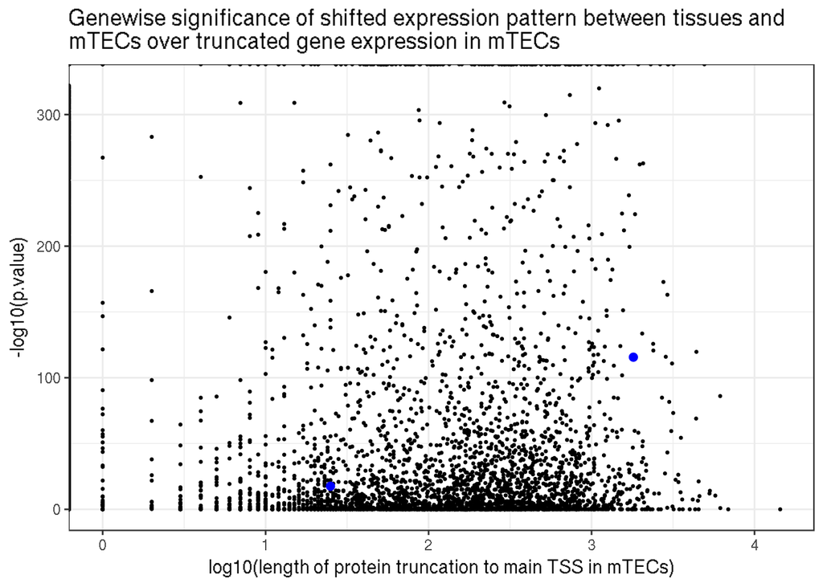

```r
#pdf(file="/home/stroemic/hiwi_16/analysis/shifted_TSS/plots/all_genes_p.value_vs_truncation.pdf")
gene_ids = c("MUC6","MLANA")
ggplot(df_genes, aes(x=log10(truncation_length), y=-log10(p.value))) +
  geom_point(size=0.5) +
  geom_point(data=df_genes[df_genes$external_gene_name %in% gene_ids,], colour="blue", size=2) +
  labs(title="Genewise significance of shifted expression pattern between tissues and \nmTECs over truncated gene expression in mTECs", x ="log10(length of protein truncation to main TSS in mTECs)", y ="-log10(p.value)") +
  theme_bw()
```

```r
#dev.off()
```